# funcharts

## Usage of funcharts

Let us show how the `funcharts` package works through an example with the dataset `air`, has been included from the R package `FRegSigCom`, used in the paper of Qi and Luo (2019). The authors propose a function-on-function regression model of the `NO2` functional variable on all the other functional variables available in the dataset. In order to show how the package works, we consider a scalar-on-function regression model, where we take the mean of `NO2` at each observation as the scalar response and all other functions as functional covariates.

### Getting multivariate functional data and the `mfd` class

We provide the `mfd` class for multivariate functional data. It inherits from the `fd` class but provides some additional features:

- It forces the coef argument to be an array when the number of functional observations and/or the number of functional variables are one
- It provides a better subset function `[` that never drops dimensions, then it always returns a `mfd` object with three-dimensional array argument coef; moreover it allows extracting observations/variables also by name
- It stores the original raw data in the long data frame format

The first thing is to get the `mfd` object from discrete data. We currently allow two types of input with the two functions:

1. `get_mfd_data.frame`: first input must be a data.frame in the long format, with:
   - one `arg` column giving the `x` values,
   - one `id` column indicating the functional observation,
   - one column per each functional variable indicating the `y` values
2. `get_mfd_list`: first input must be a list of matrices for the case all functional data are observed on the same grid, which:
   - must have all the same dimension,
   - have the variable names as name of the list,
   - are such that, for each matrix:
     - each row corresponds to a functional observation
     - each column corresponds to a point on the grid

In this example, the dataset `air` is in the second format (list of matrices, with data observed on the same grid)

```r
library(funcharts)
data("air")
fun_covariates <- names(air)[names(air) != "NO2"]
mfdobj_x <- get_mfd_list(air[fun_covariates],
                       grid = 1:24,
                       n_basis = 15,
                       lambda = 1e-2)
```

In order to perform the statistical process monitoring analysis, we divide the dataset into a phase I and a phase II dataset.

```r
rows1 <- 1:300
rows2 <- 301:355
mfdobj_x1 <- mfdobj_x[rows1]
mfdobj_x2 <- mfdobj_x[rows2]
```

Now we extract the scalar response variable, i.e. the mean of `NO2` at each observation:

```r
y <- rowMeans(air$NO2)
y1 <- y[rows1]
y2 <- y[rows2]
```

### Plotting functions

We also provide plotting functions using ggplot2. One can simply use plot function with a mfd object as input.

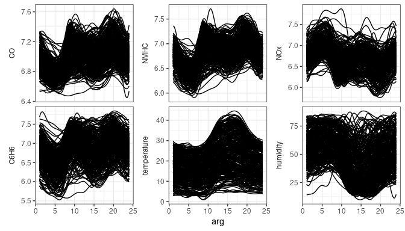

```r
plot_mfd(mfdobj_x1)
```

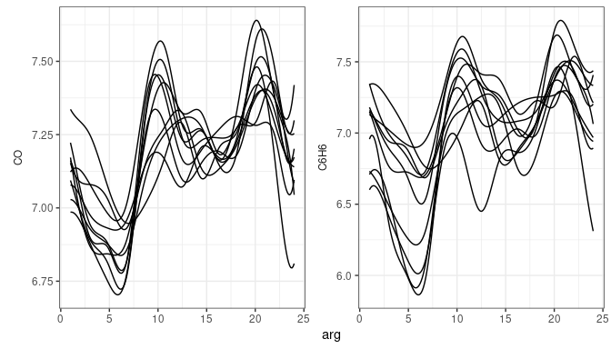

```r
plot_mfd(mfdobj_x1[1:10, c("CO", "C6H6")])
```

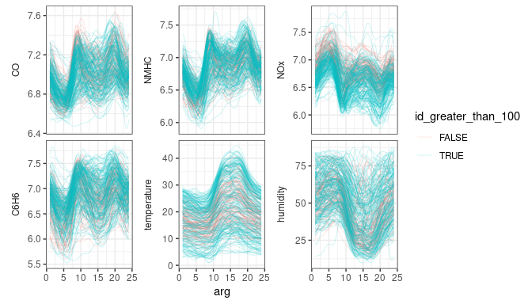

```r
dat <- data.frame(id = unique(mfdobj_x1$raw$id)) %>%
  mutate(id_greater_than_100 = as.numeric(id) > 100)
ggplot() +
  geom_mfd(mapping = aes(col = id_greater_than_100),
           mfdobj = mfdobj_x1,
           data = dat,
           alpha = .2,
           lwd = .3)
```

### Multivariate functional principal component analysis

For class `mfd` we provide a function `pca_mfd`, which is a wrapper to `pca.fd`. We also provide a plot function for eigenfunctions.

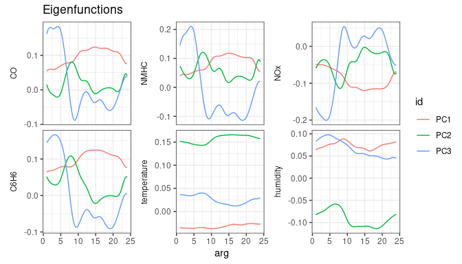

```r
pca <- pca_mfd(mfdobj_x1)
plot_pca_mfd(pca, harm = 1:3)
```

### Scalar-on-function regression based on principal components

We can build a scalar-on-function regression model where the response variable is a linear function of the multivariate functional principal components scores. The components to retain in the model can be selected with two `selection` argument. Two alternatives are available:

```r
mod <- sof_pc(y = y1, mfdobj_x = mfdobj_x1, selection = "PRESS", single_min_variance_explained = .01)
```

It is possible to plot the estimated functional regression coefficients, moreover a bootstrap approach allows to obtain uncertainty quantification, as follows

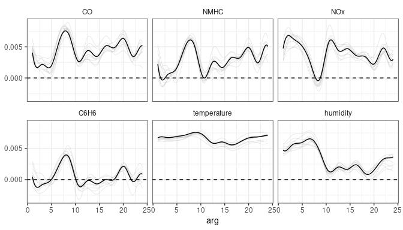

```r
plot_bootstrap_sof_pc(mod, nboot = 10, ncores = parallel::detectCores())
```

We can build control charts to monitor both functional covariates and the scalar response. We can either monitor the functional covariates alone (unsupervised monitoring) or the functional covariates and the scalar response together (supervised monitoring).

Unsupervised monitoring:

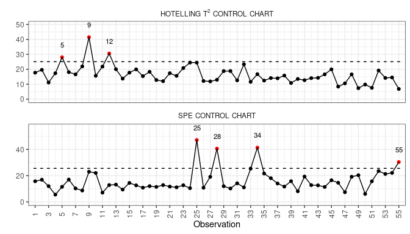

```r
cclist_pca <- control_charts_pca(pca = pca,
                                 components = mod$components,
                                 newdata = mfdobj_x2)
plot_control_charts(cclist_pca)
```

Supervised monitoring:

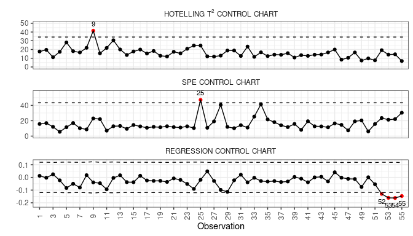

```r
cclist_sof_pc <- control_charts_sof_pc(
  mod = mod,
  mfdobj_x_test = mfdobj_x2,
  y_test = y2)
plot_control_charts(cclist_sof_pc)
```

Let us focus on the supervised monitoring. We can get the out of control observations:

```r
ooc_index <- which_ooc(cclist_sof_pc)
ooc_index
```

```
#> $T2
#>   n  id
#> 1 9 309
#>
#> $spe
#>    n  id
#> 1 25 325
#>
#> $y
#>    n  id
#> 1 52 352
#> 2 53 353
#> 3 54 354
#> 4 55 355
```

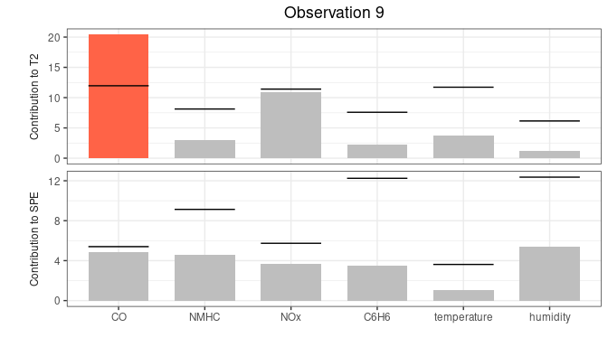

```r
cont_plot(cclist_sof_pc, 9)
```

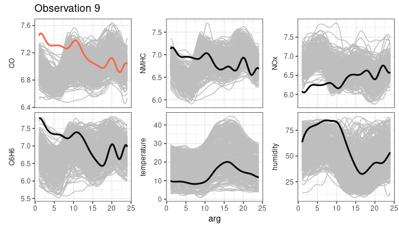

```r
plot_mon(cclist_sof_pc, mfdobj_x1, mfdobj_x2[9])
```

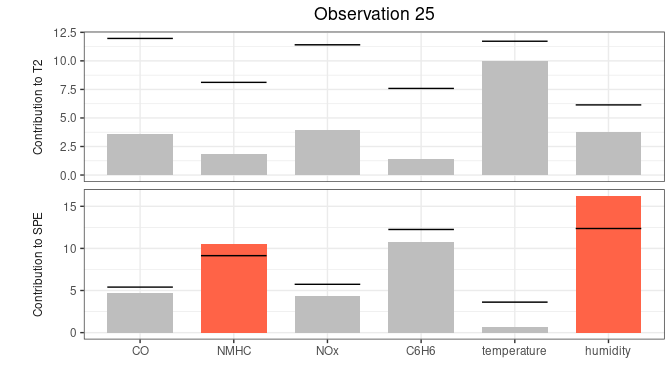

```r
cont_plot(cclist_sof_pc, 25)
```

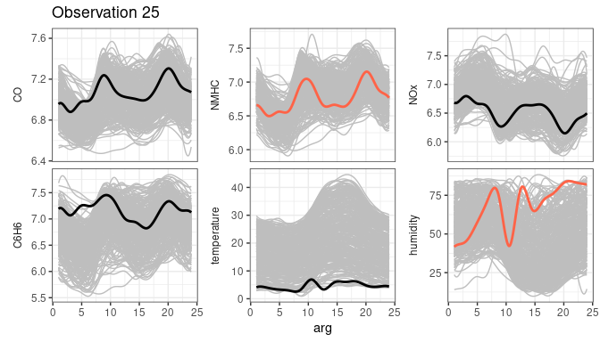

```r
plot_mon(cclist_sof_pc, mfdobj_x1, mfdobj_x2[25])
```

Moreover, observations 52, 53, 54, 55 are out of control in the regression control chart. If these observations are in control in the $T^2$ and SPE control charts, one needs to explore outside the set of functional covariates to understand the causes of the anomaly.

## Real-time monitoring

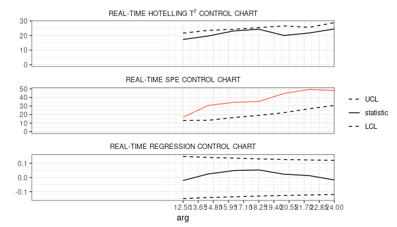

```r
mfd_list <- get_mfd_list_real_time(
  data_list = air[fun_covariates],
  grid = 1:24,
  lambda = 1e-2,
  n_instants = 7,
  start = .5
)
mfd_list1 <- lapply(mfd_list, function(x) x[rows1])
mfd_list2 <- lapply(mfd_list, function(x) x[rows2])

mod_list <- sof_pc_real_time(mfd_list1, y1, ncores = parallel::detectCores())

cc_list_real_time <- control_charts_sof_pc_real_time(
  mod_list = mod_list,
  mfdobj_x_test = mfd_list2,
  y_test = y2,
  ncores = parallel::detectCores()
)

plot_control_charts_real_time(cc_list_real_time, id_num = 25)
```

## Functional Regression Control Chart

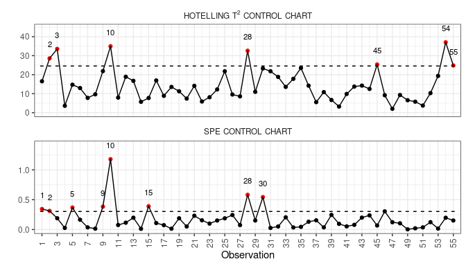

```r
library(FRegSigCom)
library(funcharts)
fun_covariates <- names(air)[names(air) != "NO2"]
mfdobj_x <- get_mfd_list(air[fun_covariates],
                         grid = 1:24,
                         n_basis = 15,
                         lambda = 1e-2,
                         ncores = parallel::detectCores())
mfdobj_y <- get_mfd_list(air["NO2"],
                         grid = 1:24,
                         n_basis = 15,
                         lambda = 1e-2,
                         ncores = parallel::detectCores())
rows1 <- 1:300
rows2 <- 301:355
mfdobj_x1 <- mfdobj_x[rows1]
mfdobj_x2 <- mfdobj_x[rows2]
mfdobj_y1 <- mfdobj_y[rows1]
mfdobj_y2 <- mfdobj_y[rows2]

mod_fof <- fof_pc(
  mfdobj_y = mfdobj_y1,
  mfdobj_x = mfdobj_x1)

frcc_df <- regr_cc_fof(
  object = mod_fof,
  mfdobj_y_new = mfdobj_y2,
  mfdobj_x_new = mfdobj_x2)

plot_control_charts(frcc_df)
```

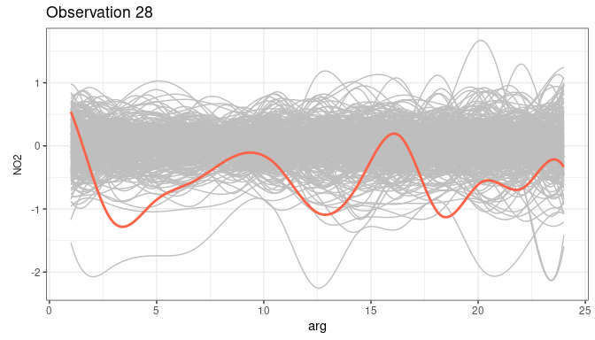

```r
y_hat <- predict_fof_pc(
  object = mod_fof,
  mfdobj_y_new = mfdobj_y2,
  mfdobj_x_new = mfdobj_x2)

plot_mon(cclist = frcc_df,
         fd_train = mod_fof$residuals,
         fd_test = y_hat$pred_error[28])
```

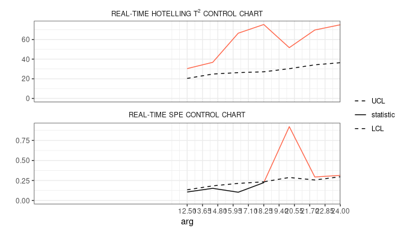

```r
mfd_list_x <- get_mfd_list_real_time(
  data_list = air[fun_covariates],
  grid = 1:24,
  lambda = 1e-2,
  n_instants = 7,
  start = .5,
  ncores = parallel::detectCores()
)

mfd_list_y <- get_mfd_list_real_time(
  data_list = air["NO2"],
  grid = 1:24,
  lambda = 1e-2,
  n_instants = 7,
  start = .5,
  ncores = parallel::detectCores()
)

mfd_list_x1 <- lapply(mfd_list_x, function(x) x[rows1])
mfd_list_x2 <- lapply(mfd_list_x, function(x) x[rows2])
mfd_list_y1 <- lapply(mfd_list_y, function(x) x[rows1])
mfd_list_y2 <- lapply(mfd_list_y, function(x) x[rows2])

mod_fof_pc_real_time_list <- fof_pc_real_time(
  mfdobj_y_list = mfd_list_y1,
  mfdobj_x_list = mfd_list_x1,
  ncores = parallel::detectCores())

cc_list_real_time <- regr_cc_fof_real_time(
  mod_list = mod_fof_pc_real_time_list,
  mfdobj_y_new_list = mfd_list_y2,
  mfdobj_x_new_list = mfd_list_x2,
  ncores = parallel::detectCores()
)

plot_control_charts_real_time(cc_list_real_time, id_num = 28)
```

# References

- Capezza C, Lepore A, Menafoglio A, Palumbo B, Vantini S. (2020). Control charts for monitoring ship operating conditions and CO~2 emissions based on scalar-on-function regression. *Applied Stochastic Models in Business and Industry*, 36(3):477–500.  
  doi:10.1002/asmb.2507
- Centofanti F, Lepore A, Menafoglio A, Palumbo B, Vantini S. (2020). Functional Regression Control Chart. *Technometrics*. doi:10.1080/00401706.2020.1753581
- Qi X, Luo R. (2019). Nonlinear function-on-function additive model with multiple predictor curves. *Statistica Sinica*, 29:719–739.